# Unsupervised Learning: Trade&Ahead

## **Data Preprocessing**

- Duplicate value check
- Missing value treatment
- Outlier check
- Feature engineering (if needed)
- Any other preprocessing steps (if needed)

**As we checked earlier there are no missing values and duplicates in the dataset**

### **Outlier Check**

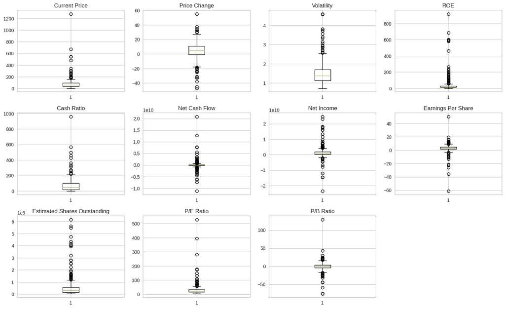

```python
# outlier detection using boxplot
# selecting the numerical columns of data and adding their names in a list
numeric_columns = stock_df2.select_dtypes(include=np.number).columns.tolist()
plt.figure(figsize=(15, 12))

for i, variable in enumerate(numeric_columns):
    plt.subplot(4, 4, i + 1)
    plt.boxplot(stock_df2[variable], whis=1.5)
    plt.tight_layout()
    plt.title(variable)

plt.show()
```

Most of the outlier present in the data are seems to be normal

### **Scaling of Dataset**

```python
# scaling the dataset before clustering
num_col = stock_df2.select_dtypes(include=np.number).columns.tolist()
scaler = StandardScaler()
subset = stock_df2[num_col].copy()
subset_scaled = scaler.fit_transform(subset)
# creating a dataframe of the scaled columns
stock_scaled_df = pd.DataFrame(subset_scaled, columns=subset.columns)
```

## **K-means Clustering**

```
Number of Clusters: 1 	Average Distortion: 2.5425069919221697
Number of Clusters: 2 	Average Distortion: 2.382318498894466
Number of Clusters: 3 	Average Distortion: 2.268294808035244
Number of Clusters: 4 	Average Distortion: 2.1770961257432995
Number of Clusters: 5 	Average Distortion: 2.1059351899972185
Number of Clusters: 6 	Average Distortion: 2.053350668955699
Number of Clusters: 7 	Average Distortion: 2.0307773675831
Number of Clusters: 8 	Average Distortion: 1.9753526418461937
Number of Clusters: 9 	Average Distortion: 1.9214330485674187
Number of Clusters: 10 	Average Distortion: 1.8563230245866948
Number of Clusters: 11 	Average Distortion: 1.799236889362526
Number of Clusters: 12 	Average Distortion: 1.7595778533441138
Number of Clusters: 13 	Average Distortion: 1.7095465252270752
Number of Clusters: 14 	Average Distortion: 1.6932638173632433
```

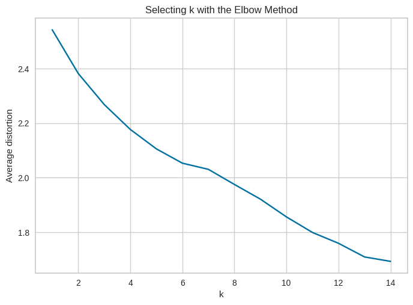

```python
clusters = range(1, 15)
meanDistortions = []

for k in clusters:
    model = KMeans(n_clusters=k)
    model.fit(stock_scaled_df)
    prediction = model.predict(stock_scaled_df)
    distortion = (
        sum(
            np.min(cdist(stock_scaled_df, model.cluster_centers_, "euclidean"), axis=1)
        )
        / stock_scaled_df.shape[0]
    )

    meanDistortions.append(distortion)

    print("Number of Clusters:", k, "\tAverage Distortion:", distortion)

plt.plot(clusters, meanDistortions, "bx-")
plt.xlabel("k")
plt.ylabel("Average distortion")
plt.title("Selecting k with the Elbow Method")
plt.show()
```

**The appropriate value of k from the elbow curve seems to be 5 or 6.**

### Let's check the silhouette scores

```
For n_clusters = 2, silhouette score is 0.43969639509980457
For n_clusters = 3, silhouette score is 0.4644405674779404
For n_clusters = 4, silhouette score is 0.4495910932182279
For n_clusters = 5, silhouette score is 0.4203446964481629
For n_clusters = 6, silhouette score is 0.4165955102007967
For n_clusters = 7, silhouette score is 0.4271728284624292
For n_clusters = 8, silhouette score is 0.3823234427493108
For n_clusters = 9, silhouette score is 0.1886263850551177
For n_clusters = 10, silhouette score is 0.21535584244233022
For n_clusters = 11, silhouette score is 0.19405928321715915
For n_clusters = 12, silhouette score is 0.12371013133256914
For n_clusters = 13, silhouette score is 0.12914387124328466
For n_clusters = 14, silhouette score is 0.14432932487344818
```

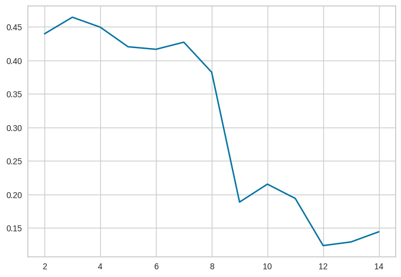

```python
sil_score = []
cluster_list = list(range(2, 15))
for n_clusters in cluster_list:
    clusterer = KMeans(n_clusters=n_clusters)
    preds = clusterer.fit_predict((stock_scaled_df))
    # centers = clusterer.cluster_centers_
    score = silhouette_score(stock_scaled_df, preds)
    sil_score.append(score)
    print("For n_clusters = {}, silhouette score is {}".format(n_clusters, score))

plt.plot(cluster_list, sil_score)
```

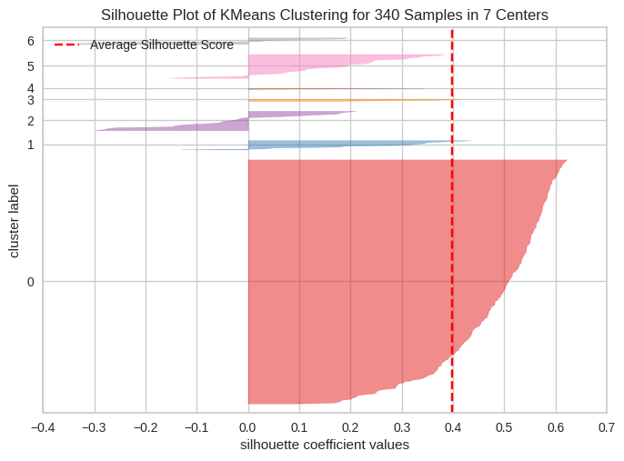

```python
# finding optimal no. of clusters with silhouette coefficients
visualizer = SilhouetteVisualizer(KMeans(7, random_state=1))
visualizer.fit(stock_scaled_df)
visualizer.show()
```

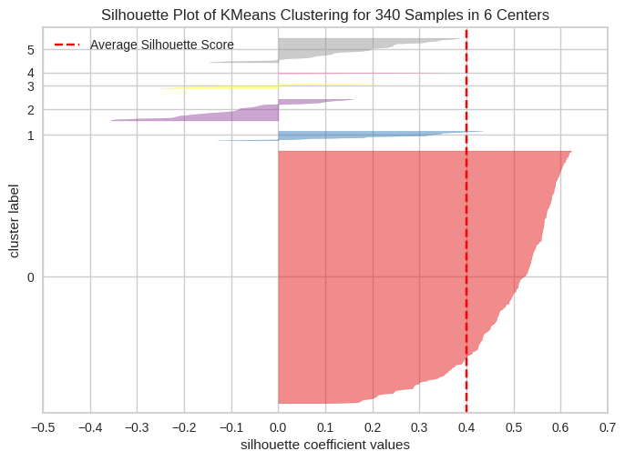

```python
# finding optimal no. of clusters with silhouette coefficients
visualizer = SilhouetteVisualizer(KMeans(6, random_state=1))
visualizer.fit(stock_scaled_df)
visualizer.show()
```

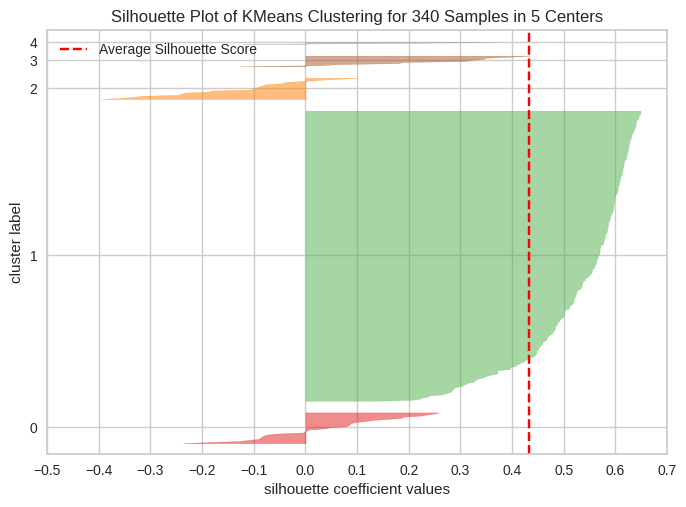

```python
# finding optimal no. of clusters with silhouette coefficients
visualizer = SilhouetteVisualizer(KMeans(5, random_state=1))
visualizer.fit(stock_scaled_df)
visualizer.show()
```

**Let's take 5 as the appropriate no. of clusters as the silhouette score is high enough and there is knick at 5 in the elbow curve.**

```python
# Let us create final model with K = 5
final_model=KMeans(5,random_state=1)
final_model.fit(stock_scaled_df)
prediction=final_model.predict(stock_scaled_df)

# adding kmeans cluster labels to the original dataframe
stock_df2["K_means_segments"] = final_model.labels_
stock_scaled_df["K_means_segments"] = final_model.labels_
```

### Cluster Profiling Kmean

```python
cluster_profile = stock_df2.groupby("K_means_segments").mean()
```

```python
cluster_profile["count_in_each_segments"] = (
   stock_df2.groupby("K_means_segments")['Security'].count().values
)
```

```python
# let's display cluster profiles
cluster_profile.style.highlight_max(color="lightgreen", axis=0)
```

| K_means_segments | Current Price | Price Change | Volatility | ROE | Cash Ratio | Net Cash Flow | Net Income | Earnings Per Share | Estimated Shares Outstanding | P/E Ratio | P/B Ratio | count_in_each_segments |
| --- | --- | --- | --- | --- | --- | --- | --- | --- | --- | --- | --- | --- |
| 0 | 65.174668 | -11.542247 | 2.690220 | 37.300000 | 65.366667 | 195008366.666667 | -1677736033.333333 | -4.401667 | 544473664.718000 | 113.488924 | 1.424161 | 30 |
| 1 | 72.738269 | 5.179897 | 1.380738 | 34.825455 | 53.138182 | -10147287.272727 | 1488641570.909091 | 3.636164 | 437961614.918582 | 23.680917 | -3.395254 | 275 |
| 2 | 233.251108 | 13.682869 | 1.719008 | 29.333333 | 296.523810 | 1398716380.952381 | 1835686380.952381 | 7.126190 | 508721791.962857 | 37.805996 | 16.758218 | 21 |
| 3 | 50.517273 | 5.747586 | 1.130399 | 31.090909 | 75.909091 | -1072272727.272727 | 14833090909.090910 | 4.154545 | 4298826628.727273 | 14.803577 | -4.552119 | 11 |
| 4 | 26.990000 | -14.060688 | 3.296307 | 603.000000 | 57.333333 | -585000000.000000 | -17555666666.666668 | -39.726667 | 481910081.666667 | 71.528835 | 1.638633 | 3 |

### Insight from Kmean clustering:

- **Cluster 0**
  - It has 30 companies.
  - P/E ratio is very high.
  - Average price change, Net Income and Earning per share is negative
  - Avergage volatility is also little high compared with other group.
  - Avergage value of stock is 65.17 and P/B ratio is 1.43
- **Cluster 1**
  - It has 275 companies.
  - P/E ratio is very good compared with other group with high ratio.
  - Average price change, Net Income and Earning per share is positive but net cashflow is negative.
  - Avergage value of stock is 72.78 and P/E ratio is 23.7.
- **Cluster 2**
  - It has 21 companies.
  - Current price,Price change, Cash ratio,Net Cash flow,Earning per share is higher compared with other group.
  - P/B ratio is very high which means it is trading very higher price compared to its book values.
  - Avergage value of stock is 233.25 and P/E ratio is 37.8.
- **Cluster 3**
  - It has 11 companies.
  - It has highest Net income and Estimated share outstanding compared with other group.
  - Current price,Price change, Cash ratio,Earning per share is positive
  - P/B ratio is very negative.
  - Avergage value of stock is 50.5 and P/E ratio is 14.8.
- **Cluster 4**
  - It has 3 companies.
  - It has highest volatility and ROE compared with other group.
  - P/B ratio is very not very high so stock price is normal to its book value.
  - Avergage value of stock is 26.99 and P/E ratio is 71.53.

```python
# Distribution of number of security based on Kmean and GIS Sector
stock_df2.groupby(["K_means_segments", "GICS Sector"])['Security'].count()
```

```
K_means_segments  GICS Sector
0                 Consumer Discretionary          1
                  Energy                         21
                  Health Care                     1
                  Industrials                     1
                  Information Technology          4
                  Materials                       2
1                 Consumer Discretionary         33
                  Consumer Staples               17
                  Energy                          5
                  Financials                     45
                  Health Care                    29
                  Industrials                    52
                  Information Technology         24
                  Materials                      18
                  Real Estate                    26
                  Telecommunications Services     2
                  Utilities                      24
2                 Consumer Discretionary          5
                  Consumer Staples                1
                  Financials                      1
                  Health Care                     8
                  Information Technology          4
                  Real Estate                     1
                  Telecommunications Services     1
3                 Consumer Discretionary          1
                  Consumer Staples                1
                  Energy                          1
                  Financials                      3
                  Health Care                     2
                  Information Technology          1
                  Telecommunications Services     2
4                 Energy                          3
Name: Security, dtype: int64
```

```python
## Number of companies in each cluster
for cl in stock_df2["K_means_segments"].unique():
    print(f'In cluster {cl}, the total number of companies present are : {stock_df2[stock_df2["K_means_segments"] == cl]["Security"].nunique()} and there names are as follows:')
    print(stock_df2[stock_df2["K_means_segments"] == cl]["Security"].unique())
    print()
```

```
In cluster 1, the total number of companies present are : 275 and there names are as follows:
['American Airlines Group' 'AbbVie' 'Abbott Laboratories'
 'Adobe Systems Inc' 'Archer-Daniels-Midland Co' 'Ameren Corp'
 'American Electric Power' 'AFLAC Inc'
 'American International Group, Inc.' 'Apartment Investment & Mgmt'
 'Assurant Inc' 'Arthur J. Gallagher & Co.' 'Akamai Technologies Inc'
 'Albemarle Corp' 'Alaska Air Group Inc' 'Allstate Corp' 'Allegion'
 'Applied Materials Inc' 'AMETEK Inc' 'Affiliated Managers Group Inc'
 'Ameriprise Financial' 'American Tower Corp A' 'AutoNation Inc'
 'Anthem Inc.' 'Aon plc' 'Amphenol Corp' 'Arconic Inc'
 'Activision Blizzard' 'AvalonBay Communities, Inc.' 'Broadcom'
 'American Water Works Company Inc' 'American Express Co' 'Boeing Company'
 'Baxter International Inc.' 'BB&T Corporation' 'Bard (C.R.) Inc.'
 'The Bank of New York Mellon Corp.' 'Ball Corp' 'Bristol-Myers Squibb'
 'Boston Scientific' 'BorgWarner' 'Boston Properties' 'Caterpillar Inc.'
 'Chubb Limited' 'CBRE Group' 'Crown Castle International Corp.'
 'Carnival Corp.' 'CF Industries Holdings Inc' 'Citizens Financial Group'
 'Church & Dwight' 'C. H. Robinson Worldwide' 'Charter Communications'
 'CIGNA Corp.' 'Cincinnati Financial' 'Colgate-Palmolive' 'Comerica Inc.'
 'CME Group Inc.' 'Cummins Inc.' 'CMS Energy' 'Centene Corporation'
 'CenterPoint Energy' 'Capital One Financial' 'The Cooper Companies'
 'CSX Corp.' 'CenturyLink Inc' 'Cognizant Technology Solutions'
 'Citrix Systems' 'CVS Health' 'Chevron Corp.' 'Dominion Resources'
 'Delta Air Lines' 'Du Pont (E.I.)' 'Deere & Co.'
 'Discover Financial Services' 'Quest Diagnostics' 'Danaher Corp.'
 'The Walt Disney Company' 'Discovery Communications-A'
 'Discovery Communications-C' 'Delphi Automotive' 'Digital Realty Trust'
 'Dun & Bradstreet' 'Dover Corp.' 'Dr Pepper Snapple Group' 'Duke Energy'
 'DaVita Inc.' 'eBay Inc.' 'Ecolab Inc.' 'Consolidated Edison'
 'Equifax Inc.' "Edison Int'l" 'Eastman Chemical' 'Equity Residential'
 'Eversource Energy' 'Essex Property Trust, Inc.' 'E*Trade'
 'Eaton Corporation' 'Entergy Corp.' 'Exelon Corp.' "Expeditors Int'l"
 'Expedia Inc.' 'Extra Space Storage' 'Fastenal Co'
 'Fortune Brands Home & Security' 'FirstEnergy Corp'
 'Fidelity National Information Services' 'Fiserv Inc' 'FLIR Systems'
 'Fluor Corp.' 'Flowserve Corporation' 'FMC Corporation'
 'Federal Realty Investment Trust' 'General Dynamics'
 'General Growth Properties Inc.' 'Corning Inc.' 'General Motors'
 'Genuine Parts' 'Garmin Ltd.' 'Goodyear Tire & Rubber'
 'Grainger (W.W.) Inc.' 'Hasbro Inc.' 'Huntington Bancshares'
```

[output cut: 61 more lines]

```
['Alliance Data Systems' 'Amgen Inc' 'Bank of America Corp'
 'BIOGEN IDEC Inc.' 'Celgene Corp.' 'Chipotle Mexican Grill' 'Equinix'
 'Edwards Lifesciences' 'Facebook' 'First Solar Inc'
 'Frontier Communications' 'Intuitive Surgical Inc.' "McDonald's Corp."
 'Monster Beverage' 'Priceline.com Inc' 'Regeneron' 'TripAdvisor'
 'Vertex Pharmaceuticals Inc' 'Waters Corporation' 'Wynn Resorts Ltd'
 'Yahoo Inc.']

In cluster 4, the total number of companies present are : 3 and there names are as follows:
['Apache Corporation' 'Chesapeake Energy' 'Devon Energy Corp.']

In cluster 3, the total number of companies present are : 11 and there names are as follows:
['Citigroup Inc.' 'Ford Motor' 'Gilead Sciences' 'Intel Corp.'
 'JPMorgan Chase & Co.' 'Coca Cola Company' 'Pfizer Inc.' 'AT&T Inc'
 'Verizon Communications' 'Wells Fargo' 'Exxon Mobil Corp.']
```

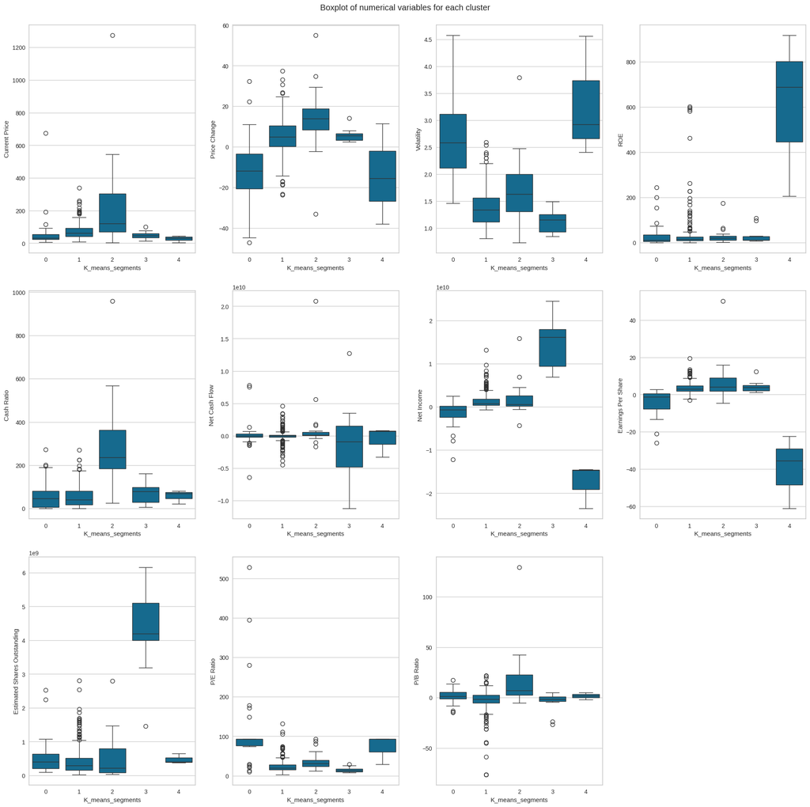

```python
# Boxplot of numerical variables for each cluster

plt.figure(figsize=(20, 20))
plt.suptitle("Boxplot of numerical variables for each cluster")

# selecting numerical columns
num_col = stock_df.select_dtypes(include=np.number).columns.tolist()

for i, variable in enumerate(num_col):
    plt.subplot(3, 4, i + 1)
    sns.boxplot(data=stock_df2, x="K_means_segments", y=variable)

plt.tight_layout(pad=2.0)
```

## **Hierarchical Clustering**

### Checking Cophenetic Correlation

```python
stock_scaled_df.head()
stock_scaled_df.drop('K_means_segments',inplace=True,axis=1)
```

```python
stock_df2.drop('K_means_segments',inplace=True,axis=1)
```

```python
stock_scaled_df.head()
```

|  | Current Price | Price Change | Volatility | ROE | Cash Ratio | Net Cash Flow | Net Income | Earnings Per Share | Estimated Shares Outstanding | P/E Ratio | P/B Ratio |
| --- | --- | --- | --- | --- | --- | --- | --- | --- | --- | --- | --- |
| 0 | -0.393341 | 0.493950 | 0.272749 | 0.989601 | -0.210698 | -0.339355 | 1.554415 | 1.309399 | 0.107863 | -0.652487 | -0.506653 |
| 1 | -0.220837 | 0.355439 | 1.137045 | 0.937737 | 0.077269 | -0.002335 | 0.927628 | 0.056755 | 1.250274 | -0.311769 | -0.504205 |
| 2 | -0.367195 | 0.602479 | -0.427007 | -0.192905 | -0.033488 | 0.454058 | 0.744371 | 0.024831 | 1.098021 | -0.391502 | 0.094941 |
| 3 | 0.133567 | 0.825696 | -0.284802 | -0.317379 | 1.218059 | -0.152497 | -0.219816 | -0.230563 | -0.091622 | 0.947148 | 0.424333 |
| 4 | -0.260874 | -0.492636 | 0.296470 | -0.265515 | 2.237018 | 0.133564 | -0.202703 | -0.374982 | 1.978399 | 3.293307 | 0.199196 |

```python
# list of distance metrics
distance_metrics = ["euclidean", "chebyshev", "mahalanobis", "cityblock"]

# list of linkage methods
linkage_methods = ["single", "complete", "average", "weighted"]

high_cophenet_corr = 0
high_dm_lm = [0, 0]

for dm in distance_metrics:
    for lm in linkage_methods:
        Z = linkage(stock_scaled_df, metric=dm, method=lm)
        c, coph_dists = cophenet(Z, pdist(stock_scaled_df))
        print(
            "Cophenetic correlation for {} distance and {} linkage is {}.".format(
                dm.capitalize(), lm, c
            )
        )
        if high_cophenet_corr < c:
            high_cophenet_corr = c
            high_dm_lm[0] = dm
            high_dm_lm[1] = lm
```

```
Cophenetic correlation for Euclidean distance and single linkage is 0.9232271494002922.
Cophenetic correlation for Euclidean distance and complete linkage is 0.7873280186580672.
Cophenetic correlation for Euclidean distance and average linkage is 0.9422540609560814.
Cophenetic correlation for Euclidean distance and weighted linkage is 0.8693784298129404.
Cophenetic correlation for Chebyshev distance and single linkage is 0.9062538164750717.
Cophenetic correlation for Chebyshev distance and complete linkage is 0.598891419111242.
Cophenetic correlation for Chebyshev distance and average linkage is 0.9338265528030499.
Cophenetic correlation for Chebyshev distance and weighted linkage is 0.9127355892367.
Cophenetic correlation for Mahalanobis distance and single linkage is 0.925919553052459.
Cophenetic correlation for Mahalanobis distance and complete linkage is 0.7925307202850002.
Cophenetic correlation for Mahalanobis distance and average linkage is 0.9247324030159736.
Cophenetic correlation for Mahalanobis distance and weighted linkage is 0.8708317490180428.
Cophenetic correlation for Cityblock distance and single linkage is 0.9334186366528574.
Cophenetic correlation for Cityblock distance and complete linkage is 0.7375328863205818.
Cophenetic correlation for Cityblock distance and average linkage is 0.9302145048594667.
Cophenetic correlation for Cityblock distance and weighted linkage is 0.731045513520281.
```

```python
# printing the combination of distance metric and linkage method with the highest cophenetic correlation
print(
    "Highest cophenetic correlation is {}, which is obtained with {} distance and {} linkage.".format(
        high_cophenet_corr, high_dm_lm[0].capitalize(), high_dm_lm[1]
    )
)
```

```
Highest cophenetic correlation is 0.9422540609560814, which is obtained with Euclidean distance and average linkage.
```

**Let's explore different linkage methods with Euclidean distance only.**

```python
# list of linkage methods
linkage_methods = ["single", "complete", "average", "centroid", "ward", "weighted"]

high_cophenet_corr = 0
high_dm_lm = [0, 0]

for lm in linkage_methods:
    Z = linkage(stock_scaled_df, metric="euclidean", method=lm)
    c, coph_dists = cophenet(Z, pdist(stock_scaled_df))
    print("Cophenetic correlation for {} linkage is {}.".format(lm, c))
    if high_cophenet_corr < c:
        high_cophenet_corr = c
        high_dm_lm[0] = "euclidean"
        high_dm_lm[1] = lm
```

```
Cophenetic correlation for single linkage is 0.9232271494002922.
Cophenetic correlation for complete linkage is 0.7873280186580672.
Cophenetic correlation for average linkage is 0.9422540609560814.
Cophenetic correlation for centroid linkage is 0.9314012446828154.
Cophenetic correlation for ward linkage is 0.7101180299865353.
Cophenetic correlation for weighted linkage is 0.8693784298129404.
```

```python
# printing the combination of distance metric and linkage method with the highest cophenetic correlation
print(
    "Highest cophenetic correlation is {}, which is obtained with {} linkage.".format(
        high_cophenet_corr, high_dm_lm[1]
    )
)
```

```
Highest cophenetic correlation is 0.9422540609560814, which is obtained with average linkage.
```

**We see that the cophenetic correlation is maximum with Euclidean distance and average linkage.**

### Checking Dendrograms

**Let's see the dendrograms for the different linkage methods.**

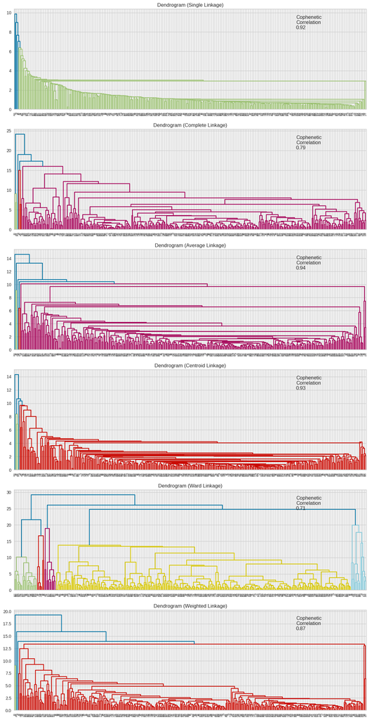

```python
# list of linkage methods
linkage_methods = ["single", "complete", "average", "centroid", "ward", "weighted"]

# lists to save results of cophenetic correlation calculation
compare_cols = ["Linkage", "Cophenetic Coefficient"]

# to create a subplot image
fig, axs = plt.subplots(len(linkage_methods), 1, figsize=(15, 30))

# We will enumerate through the list of linkage methods above
# For each linkage method, we will plot the dendrogram and calculate the cophenetic correlation
for i, method in enumerate(linkage_methods):
    Z = linkage(stock_scaled_df, metric="euclidean", method=method)

    dendrogram(Z, ax=axs[i])
    axs[i].set_title(f"Dendrogram ({method.capitalize()} Linkage)")

    coph_corr, coph_dist = cophenet(Z, pdist(stock_scaled_df))
    axs[i].annotate(
        f"Cophenetic\nCorrelation\n{coph_corr:0.2f}",
        (0.80, 0.80),
        xycoords="axes fraction",
    )
```

Observations

- The cophenetic correlation is highest for average.
- Ward linkage has more distinct and separated clusters (as seen from it's dendrogram before). 5 appears to be the appropriate number of clusters from the dendrogram for Ward linkage.

**We will move ahead with Ward linkage with 5 clusters.**

### Creating Model using sklearn

```python
HCmodel = AgglomerativeClustering(n_clusters=5, affinity="euclidean", linkage="ward")
HCmodel.fit(stock_scaled_df)
```

```
AgglomerativeClustering(affinity='euclidean', n_clusters=5)
```

```python
stock_scaled_df["HC_Clusters"] = HCmodel.labels_
stock_df2["HC_Clusters"] = HCmodel.labels_
```

### Cluster Profiling for Agglomerative Clustering

```python
cluster_profile2 = stock_df2.groupby("HC_Clusters").mean()
```

```python
cluster_profile2["count_in_each_segments"] = (
   stock_df2.groupby("HC_Clusters")['Security'].count().values
)
```

```python
# lets display cluster profile
cluster_profile2.style.highlight_max(color="lightgreen", axis=0)
```

| HC_Clusters | Current Price | Price Change | Volatility | ROE | Cash Ratio | Net Cash Flow | Net Income | Earnings Per Share | Estimated Shares Outstanding | P/E Ratio | P/B Ratio | count_in_each_segments |
| --- | --- | --- | --- | --- | --- | --- | --- | --- | --- | --- | --- | --- |
| 0 | 326.198218 | 10.563242 | 1.642560 | 14.400000 | 309.466667 | 288850666.666667 | 864498533.333333 | 7.785333 | 544900261.301333 | 113.095334 | 19.142151 | 15 |
| 1 | 84.355716 | 3.854981 | 1.827670 | 633.571429 | 33.571429 | -568400000.000000 | -4968157142.857142 | -10.841429 | 398169036.442857 | 42.284541 | -11.589502 | 7 |
| 2 | 42.848182 | 6.270446 | 1.123547 | 22.727273 | 71.454545 | 558636363.636364 | 14631272727.272728 | 3.410000 | 4242572567.290909 | 15.242169 | -4.924615 | 11 |
| 3 | 72.760400 | 5.213307 | 1.427078 | 25.603509 | 60.392982 | 79951512.280702 | 1538594322.807018 | 3.655351 | 446472132.228456 | 24.722670 | -2.647194 | 285 |
| 4 | 36.440455 | -16.073408 | 2.832884 | 57.500000 | 42.409091 | -472834090.909091 | -3161045227.272727 | -8.005000 | 514367806.201818 | 85.555682 | 0.836839 | 22 |

### Insight from Hierarchical Clustering:

- **Cluster 0**
  - It has 15 companies.
  - Current Price,Price Change, Cash Ratio,Earning Per Share is very high compared with other group
  - P/E and P/B ratio is very high means stock price is very high compared with its earning and book value.
  - Avergage value of stock is 326.2 and P/E ratio is 113.1
- **Cluster 1**
  - It has 7 companies.
  - ROE is very high.
  - Net Income,Net Cash Flow and Earning per share is negative.
  - Avergage value of stock is 84.33 and P/E ratio is 42.3.
- **Cluster 2**
  - It has 11 companies.
  - Net Income and Net Cash Flow is very high compared with other group
  - P/E ratio is very good compared with other group.
  - Avergage value of stock is 42.9 and P/E ratio is 15.24.
- **Cluster 3**
  - It has 285 companies.
  - It has decent values for Price change, Cash ratio,Earning per share, Net income and Estimated share outstanding compared with other group.
  - Current price,Price change, Cash ratio,Earning per share is positive
  - Avergage value of stock is 72.8 and P/E ratio is 24.7.
- **Cluster 4**
  - It has 22 companies.
  - It has highest volatility compared with other group.P/E ratio is also high.
  - P/B ratio is less then 1 means stock price is low compared to its book value.
  - Avergage value of stock is 36.44 and P/E ratio is 85.56.

```python
# Chcking count of Security based on HC_Cluster and GICS Sector
stock_df2.groupby(["HC_Clusters", "GICS Sector"])['Security'].count()
```

```
HC_Clusters  GICS Sector
0            Consumer Discretionary          3
             Consumer Staples                1
             Health Care                     5
             Information Technology          4
             Real Estate                     1
             Telecommunications Services     1
1            Consumer Discretionary          1
             Consumer Staples                2
             Energy                          2
             Financials                      1
             Industrials                     1
2            Consumer Discretionary          1
             Consumer Staples                1
             Energy                          1
             Financials                      4
             Health Care                     1
             Information Technology          1
             Telecommunications Services     2
3            Consumer Discretionary         35
             Consumer Staples               15
             Energy                          7
             Financials                     44
             Health Care                    34
             Industrials                    52
             Information Technology         27
             Materials                      19
             Real Estate                    26
             Telecommunications Services     2
             Utilities                      24
4            Energy                         20
             Information Technology          1
             Materials                       1
Name: Security, dtype: int64
```

```python
## Complete the code to print the companies in each cluster
for cl in stock_df2["HC_Clusters"].unique():
    print("In cluster {}, the following companies are present:".format(cl))
    print(stock_df2[stock_df2["HC_Clusters"] == cl]["Security"].unique())
    print()
```

```
In cluster 3, the following companies are present:
['American Airlines Group' 'AbbVie' 'Abbott Laboratories'
 'Adobe Systems Inc' 'Analog Devices, Inc.' 'Archer-Daniels-Midland Co'
 'Ameren Corp' 'American Electric Power' 'AFLAC Inc'
 'American International Group, Inc.' 'Apartment Investment & Mgmt'
 'Assurant Inc' 'Arthur J. Gallagher & Co.' 'Akamai Technologies Inc'
 'Albemarle Corp' 'Alaska Air Group Inc' 'Allstate Corp'
 'Applied Materials Inc' 'AMETEK Inc' 'Affiliated Managers Group Inc'
 'Ameriprise Financial' 'American Tower Corp A' 'AutoNation Inc'
 'Anthem Inc.' 'Aon plc' 'Amphenol Corp' 'Arconic Inc'
 'Activision Blizzard' 'AvalonBay Communities, Inc.' 'Broadcom'
 'American Water Works Company Inc' 'American Express Co' 'Boeing Company'
 'Baxter International Inc.' 'BB&T Corporation' 'Bard (C.R.) Inc.'
 'BIOGEN IDEC Inc.' 'The Bank of New York Mellon Corp.' 'Ball Corp'
 'Bristol-Myers Squibb' 'Boston Scientific' 'BorgWarner'
 'Boston Properties' 'Caterpillar Inc.' 'Chubb Limited' 'CBRE Group'
 'Crown Castle International Corp.' 'Carnival Corp.' 'Celgene Corp.'
 'CF Industries Holdings Inc' 'Citizens Financial Group' 'Church & Dwight'
 'C. H. Robinson Worldwide' 'CIGNA Corp.' 'Cincinnati Financial'
 'Comerica Inc.' 'CME Group Inc.' 'Cummins Inc.' 'CMS Energy'
 'Centene Corporation' 'CenterPoint Energy' 'Capital One Financial'
 'The Cooper Companies' 'CSX Corp.' 'CenturyLink Inc'
 'Cognizant Technology Solutions' 'Citrix Systems' 'CVS Health'
 'Chevron Corp.' 'Dominion Resources' 'Delta Air Lines' 'Du Pont (E.I.)'
 'Deere & Co.' 'Discover Financial Services' 'Quest Diagnostics'
 'Danaher Corp.' 'The Walt Disney Company' 'Discovery Communications-A'
 'Discovery Communications-C' 'Delphi Automotive' 'Digital Realty Trust'
 'Dun & Bradstreet' 'Dover Corp.' 'Dr Pepper Snapple Group' 'Duke Energy'
 'DaVita Inc.' 'eBay Inc.' 'Ecolab Inc.' 'Consolidated Edison'
 'Equifax Inc.' "Edison Int'l" 'Eastman Chemical' 'Equity Residential'
 'EQT Corporation' 'Eversource Energy' 'Essex Property Trust, Inc.'
 'E*Trade' 'Eaton Corporation' 'Entergy Corp.' 'Edwards Lifesciences'
 'Exelon Corp.' "Expeditors Int'l" 'Expedia Inc.' 'Extra Space Storage'
 'Fastenal Co' 'Fortune Brands Home & Security' 'FirstEnergy Corp'
 'Fidelity National Information Services' 'Fiserv Inc' 'FLIR Systems'
 'Fluor Corp.' 'Flowserve Corporation' 'FMC Corporation'
 'Federal Realty Investment Trust' 'First Solar Inc' 'General Dynamics'
 'General Growth Properties Inc.' 'Gilead Sciences' 'Corning Inc.'
 'General Motors' 'Genuine Parts' 'Garmin Ltd.' 'Goodyear Tire & Rubber'
 'Grainger (W.W.) Inc.' 'Halliburton Co.' 'Hasbro Inc.'
```

[output cut: 61 more lines]

```
 'S&P Global, Inc.']

In cluster 4, the following companies are present:
['Anadarko Petroleum Corp' 'Baker Hughes Inc' 'Cabot Oil & Gas'
 'Concho Resources' 'Devon Energy Corp.' 'EOG Resources'
 'Freeport-McMoran Cp & Gld' 'Hess Corporation' 'Kinder Morgan'
 'Marathon Oil Corp.' 'Murphy Oil' 'Noble Energy Inc'
 'Newfield Exploration Co' 'National Oilwell Varco Inc.' 'ONEOK'
 'Occidental Petroleum' 'Range Resources Corp.' 'Spectra Energy Corp.'
 'Southwestern Energy' 'Teradata Corp.' 'Williams Cos.' 'Cimarex Energy']

In cluster 2, the following companies are present:
['Bank of America Corp' 'Citigroup Inc.' 'Ford Motor' 'Intel Corp.'
 'JPMorgan Chase & Co.' 'Coca Cola Company' 'Pfizer Inc.' 'AT&T Inc'
 'Verizon Communications' 'Wells Fargo' 'Exxon Mobil Corp.']
```

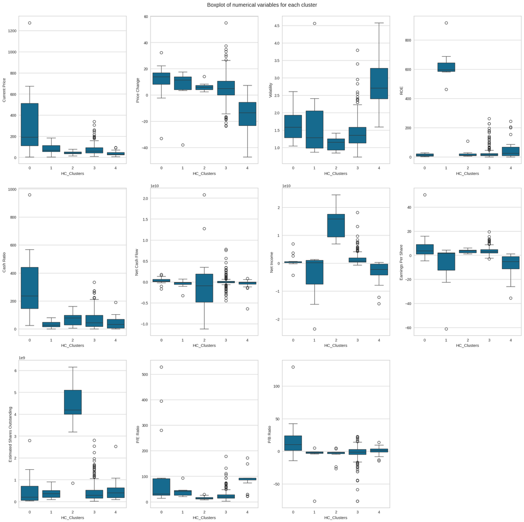

```python
# Boxplot of numerical variables for each cluster

plt.figure(figsize=(20, 20))
plt.suptitle("Boxplot of numerical variables for each cluster")

# selecting numerical columns
num_col = stock_df.select_dtypes(include=np.number).columns.tolist()

for i, variable in enumerate(num_col):
    plt.subplot(3, 4, i + 1)
    sns.boxplot(data=stock_df2, x="HC_Clusters", y=variable)

plt.tight_layout(pad=2.0)
```

## **K-means vs Hierarchical Clustering**

**1) Which clustering technique took less time for execution?**

K-means was little fast as we specify the number of cluster in advance we need and Hierarchical Clustering took little more time to execute.

**2) Which clustering technique gave you more distinct clusters, or are they the same?**

For K mean clustering Group 1 has 275 companies while In Hierarchical clustering Group 3 has 285 companies which include almost 80% of the companies in the dataset.Both the group 1 from Kmean clustering and group 3 from Hierarchical clustering has almost similar Current Price,Price Change,Volatility,Earning per Share and P/E ratio.For K mean clustering Group 3 has 11 companies while In Hierarchical clustering Group 2 has 11 companies.Both the group 3 from Kmean clustering and group 2 from Hierarchical clustering has almost similar Volatility,Earning per Share,Net Income,Estimated Share Outstanding,P/E Ratio and P/B ratio.

K mean Cluster

- Group 0 - 30
- Group 1 - 275
- Group 2 - 21
- Group 3 - 11
- Group 4 - 3

Hierarchical clustering

- Group 0 - 15
- Group 1 - 7
- Group 2 - 11
- Group 3 - 285
- Group 4 - 22

**4) How many clusters are obtained as the appropriate number of clusters from both algorithms?**

From both the clustering technique I got 5 as appropriate number of cluster.

## Actionable Insights and Recommendations

- Trade&Ahead should first understand there clients financial goal and risk taking power before they assign them to any clusters we found
- Trade&Ahead should put client in the cluster 0 of Hierchical cluster or cluster 2 of Kmean cluster if they want stocks with high Cash ratio,more volatility and ready to buy high price stock . It has high P/E ratio which is not that good but if the client wants more positive price change and ready for risk then this is good fit for them.
- Trade&Ahead should put client in the cluster 2 of Hierchical cluster or cluster 3 of Kmean cluster if they want stocks with good P/E ratio of around 15 and positive net income. This is good fit for client who does not want much volatility and wants to take low risk.
- Trade&Ahead should put client in the cluster 3 of Hierchical cluster or cluster 1 of Kmean cluster if they wants very ballanced portfolio with large number of stocks which inturn has very less volatility.This will be really good fit for older client.
- Trade&Ahead should not suggest client with cluster 4 from both the method as it has negative price change over last 13 weeks and very high volatility.
- Trade&Ahead should analyze some more number of stocks to get more diversity in the portfolio.